# Hankowsky_HW2

2022-09-14

Hankowsky Homework Solutions

# Basic Problems

## 2.22

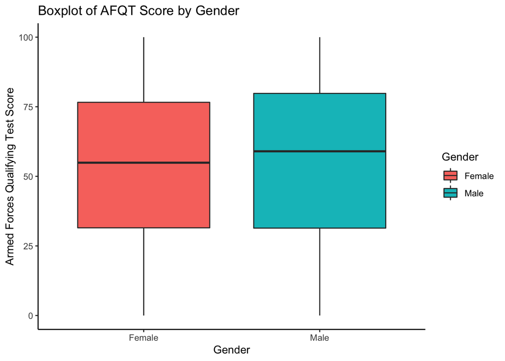

```r
#pulling the data from the 'Sleuth 3' package
intelligence <- Sleuth3::ex0222

#transposing the data so it is in long format
intelligence <- intelligence %>%
  mutate(Gender = str_to_title(Gender)) %>%
  pivot_longer(cols = c(Arith, Word, Parag, Math),
               names_to = "test",
               values_to = "score")

#boxplot of overall AFQT score by gender
intelligence %>%
  ggplot() +
  geom_boxplot(aes(x = Gender, y = AFQT, fill = Gender)) +
  labs(title = "Boxplot of AFQT Score by Gender",
    y = "Armed Forces Qualifying Test Score") +
  theme_classic()
```

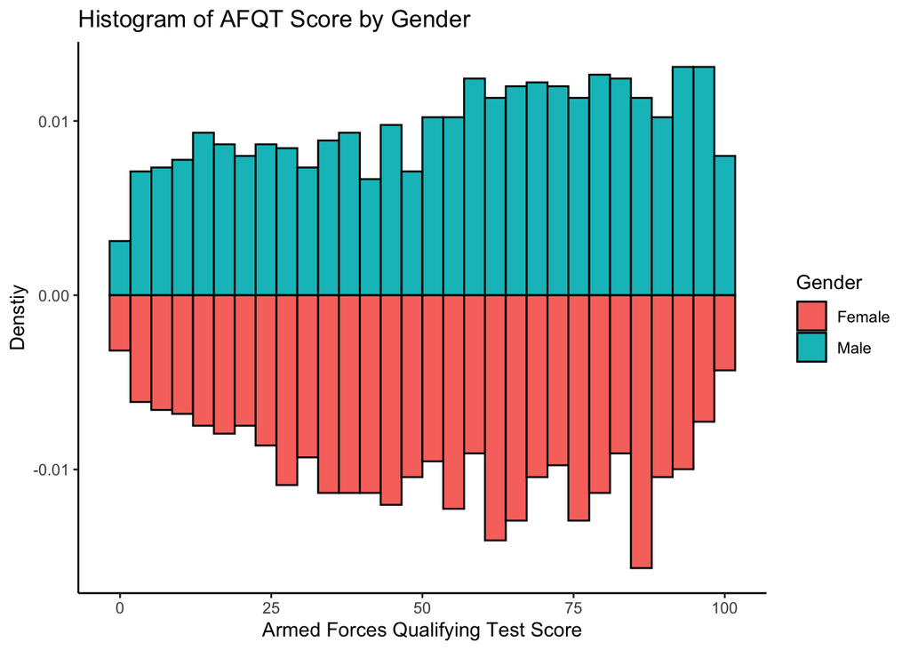

```r
#histogram of AFQT score by gender
ggplot() +
  geom_histogram(data = intelligence %>%
                   filter(Gender == "Male"),
                 aes(x = AFQT, y = ..density.., fill = Gender), color = "black") +
  geom_histogram(data = intelligence %>%
                   filter(Gender == "Female"),
                 aes(x = AFQT, y = -..density.., fill = Gender), color = "black") +
  labs(title = "Histogram of AFQT Score by Gender",
    x = "Armed Forces Qualifying Test Score", y = "Denstiy") +
  theme_classic()
```

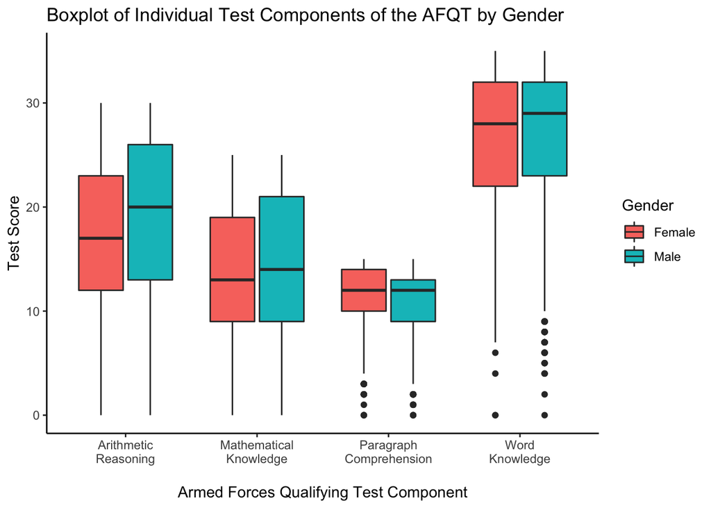

```r
#boxplot of individual test components by gender
intelligence %>%
  ggplot() +
  geom_boxplot(aes(x = test, y = score, fill = Gender)) +
  scale_x_discrete(labels = c("Arithmetic\nReasoning", "Mathematical\nKnowledge", "Paragraph\nComprehension", "Word\nKnowledge")) +
  labs(title = "Boxplot of Individual Test Components of the AFQT by Gender",
    x = "\nArmed Forces Qualifying Test Component", y = "Test Score") +
  theme_classic()
```

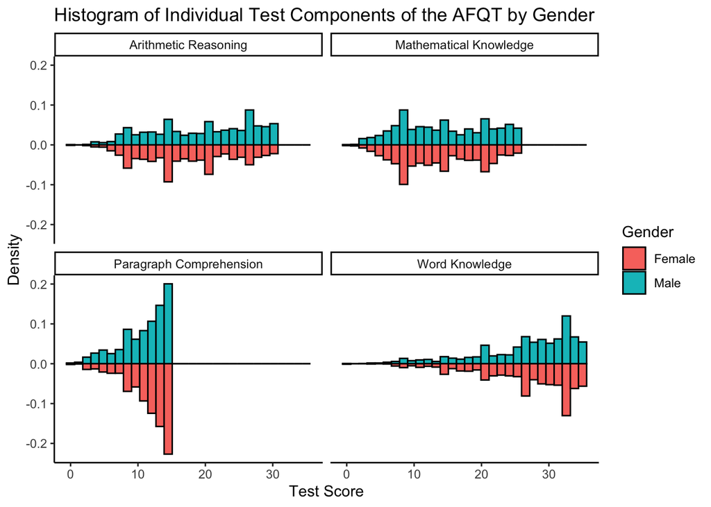

```r
#histogram of individual test components by gender
ggplot() +
  geom_histogram(data = intelligence %>%
                   filter(Gender == "Male"),
                 aes(x = score, y = ..density.., fill = Gender), color = "black") +
  geom_histogram(data = intelligence %>%
                   filter(Gender == "Female"),
                 aes(x = score, y = -..density.., fill = Gender), color = "black") +
  labs(title = "Histogram of Individual Test Components of the AFQT by Gender",
       x = "Test Score", y = "Density") +
  theme_classic() +
  facet_wrap(~test,
             labeller = as_labeller(c(
               Arith = "Arithmetic Reasoning",
               Math = "Mathematical Knowledge",
               Parag = "Paragraph Comprehension",
               Word = "Word Knowledge")))
```

```r
#running the t-test to see if there is a difference in AFQT score by gender
#turning the gender variable into a factor
intel_t <- intelligence %>%
  mutate(Gender = as.factor(Gender))

#running the actual t-test
t.test(AFQT ~ Gender, var.equal = TRUE, data = intel_t)
```

```
##
##  Two Sample t-test
##
## data:  AFQT by Gender
## t = -3.7389, df = 10334, p-value = 0.0001858
## alternative hypothesis: true difference in means between group Female and group Male is not equal to 0
## 95 percent confidence interval:
##  -3.1102017 -0.9707138
## sample estimates:
## mean in group Female   mean in group Male
##             53.40579             55.44625
```

```r
#now looking at potential differences in each test component
#creating a dataset for each test component
intel_t_arith <- intelligence %>%
  mutate(Gender = as.factor(Gender)) %>%
  filter(test == "Arith")

intel_t_word <- intelligence %>%
  mutate(Gender = as.factor(Gender)) %>%
  filter(test == "Word")

intel_t_parag <- intelligence %>%
  mutate(Gender = as.factor(Gender)) %>%
  filter(test == "Parag")

intel_t_math <- intelligence %>%
  mutate(Gender = as.factor(Gender)) %>%
  filter(test == "Math")


#running a t-test for each test component
#arith
t.test(score ~ Gender, var.equal = TRUE, data = intel_t_arith)
```

```
##
##  Two Sample t-test
##
## data:  score by Gender
## t = -7.3064, df = 2582, p-value = 3.639e-13
## alternative hypothesis: true difference in means between group Female and group Male is not equal to 0
## 95 percent confidence interval:
##  -2.583758 -1.490353
## sample estimates:
## mean in group Female   mean in group Male
##             17.48592             19.52297
```

```r
#word
t.test(score ~ Gender, var.equal = TRUE, data = intel_t_word)
```

```
##
##  Two Sample t-test
##
## data:  score by Gender
## t = 0.079805, df = 2582, p-value = 0.9364
## alternative hypothesis: true difference in means between group Female and group Male is not equal to 0
## 95 percent confidence interval:
##  -0.5217027  0.5659693
## sample estimates:
## mean in group Female   mean in group Male
##             26.56808             26.54594
```

```r
#parag
t.test(score ~ Gender, var.equal = TRUE, data = intel_t_parag)
```

```
##
##  Two Sample t-test
##
## data:  score by Gender
## t = 4.5968, df = 2582, p-value = 4.497e-06
## alternative hypothesis: true difference in means between group Female and group Male is not equal to 0
## 95 percent confidence interval:
##  0.3265415 0.8123791
## sample estimates:
## mean in group Female   mean in group Male
##             11.48983             10.92037
```

```r
#math
t.test(score ~ Gender, var.equal = TRUE, data = intel_t_math)
```

```
##
##  Two Sample t-test
##
## data:  score by Gender
## t = -3.0464, df = 2582, p-value = 0.002339
## alternative hypothesis: true difference in means between group Female and group Male is not equal to 0
## 95 percent confidence interval:
##  -1.236111 -0.267979
## sample estimates:
## mean in group Female   mean in group Male
##             13.81534             14.56738
```

The variance of the genders are about equal, so an equal variance two sample t-test was used. The histogram shows that both genders have a relatively uniform distributed, however, the two-sample t-test is robust to violations of normally distributed samples, so the analysis proceeded with an equal variance two sample t-test.These data provide strong evidence for a difference in male and female scoring on the overall Armed Forces Qualifying Test (two-sided p-value < 0.001 from an equal variance two-sample t-test). The mean score for males on the AFQT was 2.04 points greater than the mean female score (95% confidence interval: 0.97 to 3.11 points).

The variance between gender was about equal for each of the individual components of the AFQT, so an equal variance two sample t-test was used. The histograms for the individual components of the test were again relatively uniform with the exception of the ‘Paragraph Comprehension’ section. However, the two-sample t-test is robust to violations of normally distributed samples, so the analysis again proceeded with an equal variance two sample t-test.There was overwhelming evidence that Arithmetic Reasoning section score differed by gender (p-value < 0.000001 from an equal variance two-sample t-test) with the mean score for males 2.04 points higher than the female score (95% confidence interval: 1.49 to 2.58 points). The Paragraph Comprehension section also had overwhelming evidence that the score differed by gender (p-value < 0.00001 from an equal variance two-sample t-test). The mean female score was 0.57 points greater than the mean male score (95% confidence interval 0.33 to 0.81 points). There was strong evidence for a difference in male and female test scores for the Mathematical Knowledge component as well (p-value = 0.0023 from an equal variance two-sample t-test) with the mean male score 0.75 points higher than the mean female score (95% confidence interval: 0.27 to 1.24 points). There was no evidence for a difference in male and female scoring on the Word Knowledge section (p-value = 0.94 from an equal variance two-sample t-test).

## 3.32

#### A

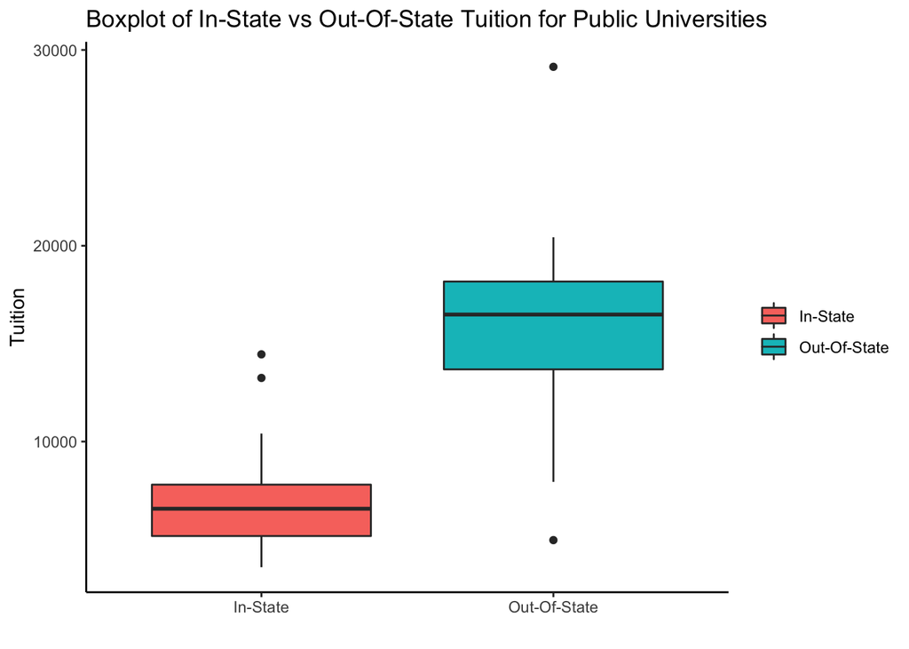

```r
#pulling the data from the 'Sleuth 3' package
tuition <- Sleuth3::ex0332

#creating a column with the difference of outofstate tuition minus instate tuition
tuition <- tuition %>%
  mutate(diff = OutOfState - InState)

#transposing the data so it's in long format
tuition_long <- tuition %>%
  pivot_longer(cols = c(InState, OutOfState),
               names_to = "State",
               values_to = "Tuition")  %>%
  mutate(log_tuition = log(Tuition))


#boxplot of in-state v out-of-state tuition for public universities
tuition_long %>%
  filter( Type == "Public") %>%
  ggplot() +
  geom_boxplot(aes(x = State, y = Tuition, fill = State)) +
  scale_x_discrete(labels = c("In-State", "Out-Of-State")) +
  scale_fill_discrete(name = "", labels = c("In-State", "Out-Of-State")) +
  labs(title = "Boxplot of In-State vs Out-Of-State Tuition for Public Universities",
       x = "") +
  theme_classic()
```

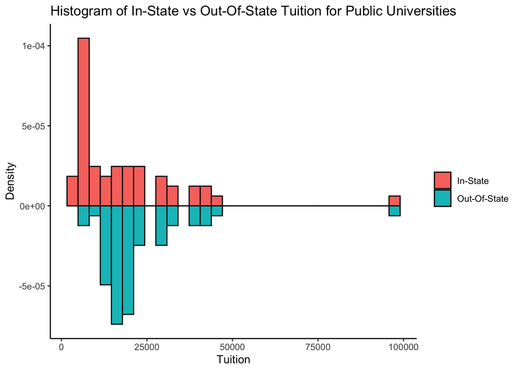

```r
#histogram of in-state v out-of-state tuition for public universities
tuition_long %>%
  filter( Type == "Public") %>%
  ggplot() +
  geom_histogram(data = tuition_long %>%
                   filter(State == "InState"),
                 aes(x = Tuition, y = ..density.., fill = State), color = "black") +
  geom_histogram(data = tuition_long %>%
                   filter(State == "OutOfState"),
                 aes(x = Tuition, y = -..density.., fill = State), color = "black") +
  scale_fill_discrete(name = "", labels = c("In-State", "Out-Of-State")) +
  labs(title = "Histogram of In-State vs Out-Of-State Tuition for Public Universities",
       y = "Density") +
  theme_classic()
```

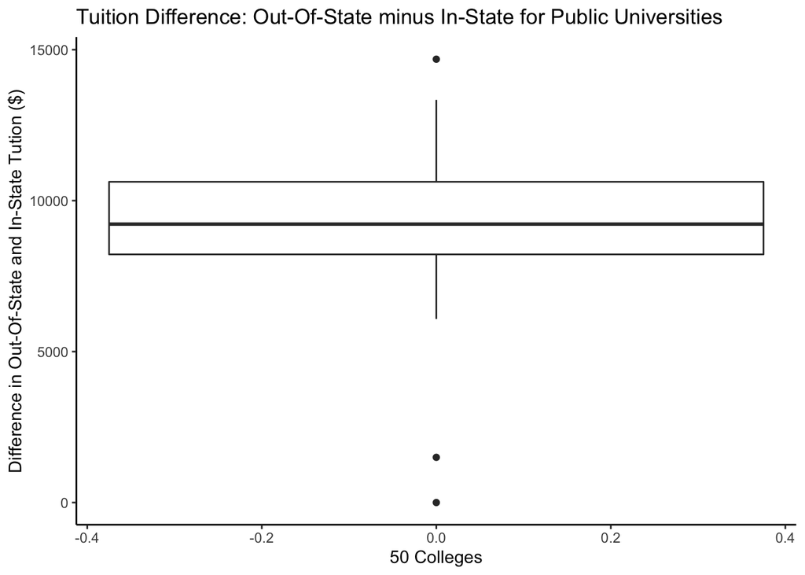

```r
#boxplot of the difference in tuitions
tuition %>%
  filter(Type == "Public") %>%
  ggplot() +
  geom_boxplot(aes(y = diff)) +
  labs(title = "Tuition Difference: Out-Of-State minus In-State for Public Universities",
       y = "Difference in Out-Of-State and In-State Tution ($)",
       x = "50 Colleges") +
  theme_classic()
```

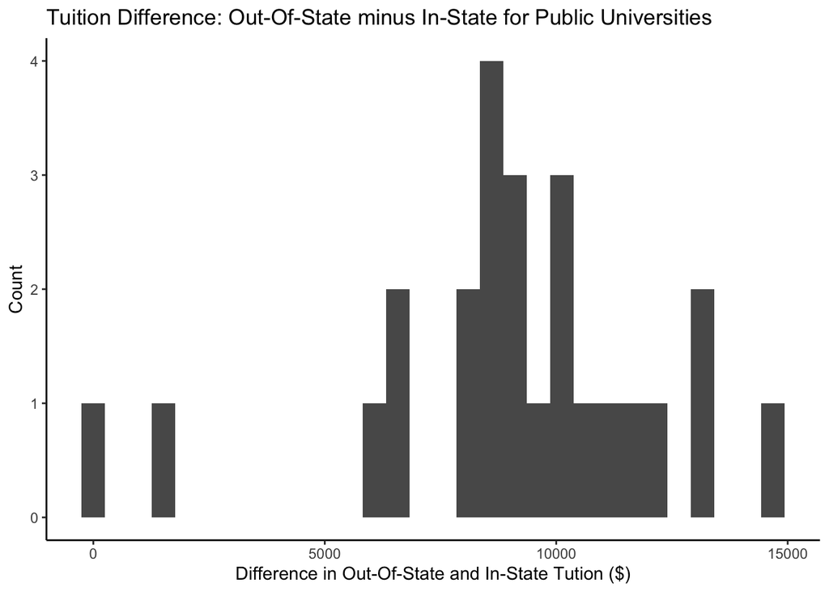

```r
#histogram of the difference in tuitions
tuition %>%
  filter(Type == "Public") %>%
  ggplot() +
  geom_histogram(aes(x = diff)) +
  labs(title = "Tuition Difference: Out-Of-State minus In-State for Public Universities",
       x = "Difference in Out-Of-State and In-State Tution ($)",
       y = "Count") +
  theme_classic()
```

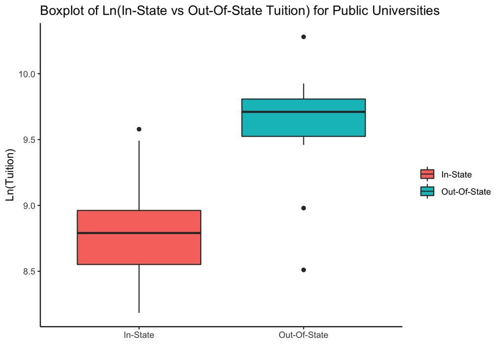

```r
#log transforming the data and looking at the difference of logs
tuition <- tuition %>%
  mutate(log_outofstate = log(OutOfState),
         log_instate = log(InState),
         diff_of_logs = log_outofstate - log_instate)



#boxplot of in-state v out-of-state tuition for public universities
tuition_long %>%
  filter( Type == "Public") %>%
  ggplot() +
  geom_boxplot(aes(x = State, y = log_tuition, fill = State)) +
  scale_x_discrete(labels = c("In-State", "Out-Of-State")) +
  scale_fill_discrete(name = "", labels = c("In-State", "Out-Of-State")) +
  labs(title = "Boxplot of Ln(In-State vs Out-Of-State Tuition) for Public Universities",
       x = "", y = "Ln(Tuition)") +
  theme_classic()
```

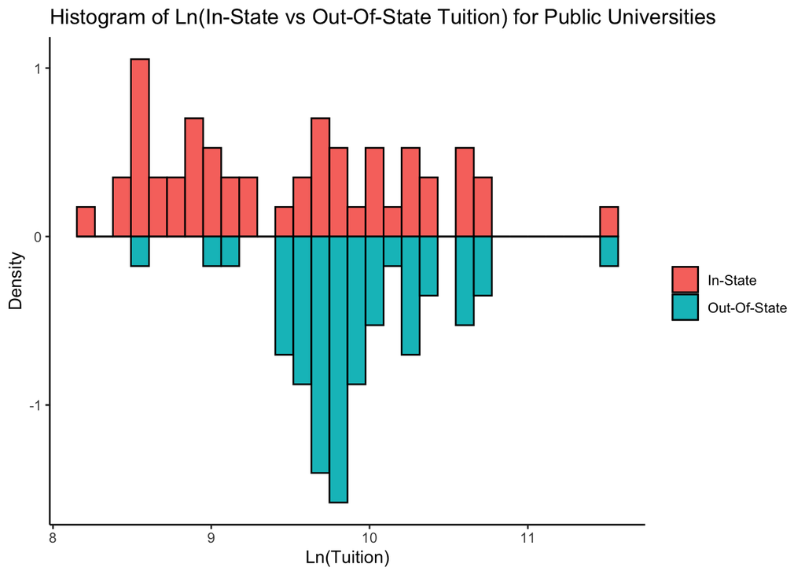

```r
#histogram of in-state v out-of-state tuition for public universities
tuition_long %>%
  filter( Type == "Public") %>%
  ggplot() +
  geom_histogram(data = tuition_long %>%
                   filter(State == "InState"),
                 aes(x = log_tuition, y = ..density.., fill = State), color = "black") +
  geom_histogram(data = tuition_long %>%
                   filter(State == "OutOfState"),
                 aes(x = log_tuition, y = -..density.., fill = State), color = "black") +
  scale_fill_discrete(name = "", labels = c("In-State", "Out-Of-State")) +
  labs(title = "Histogram of Ln(In-State vs Out-Of-State Tuition) for Public Universities",
       y = "Density", x = "Ln(Tuition)") +
  theme_classic()
```

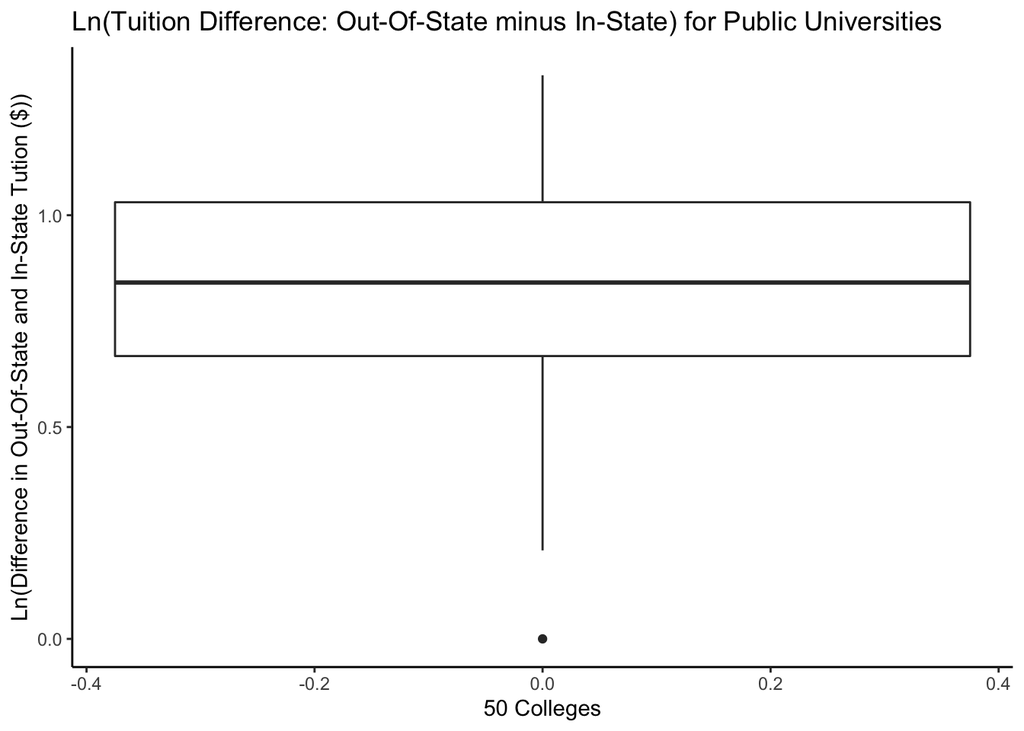

```r
#boxplot of the difference in logged tuition
tuition %>%
  filter(Type == "Public") %>%
  ggplot() +
  geom_boxplot(aes(y = diff_of_logs)) +
  labs(title = "Ln(Tuition Difference: Out-Of-State minus In-State) for Public Universities",
       y = "Ln(Difference in Out-Of-State and In-State Tution ($))",
       x = "50 Colleges") +
  theme_classic()
```

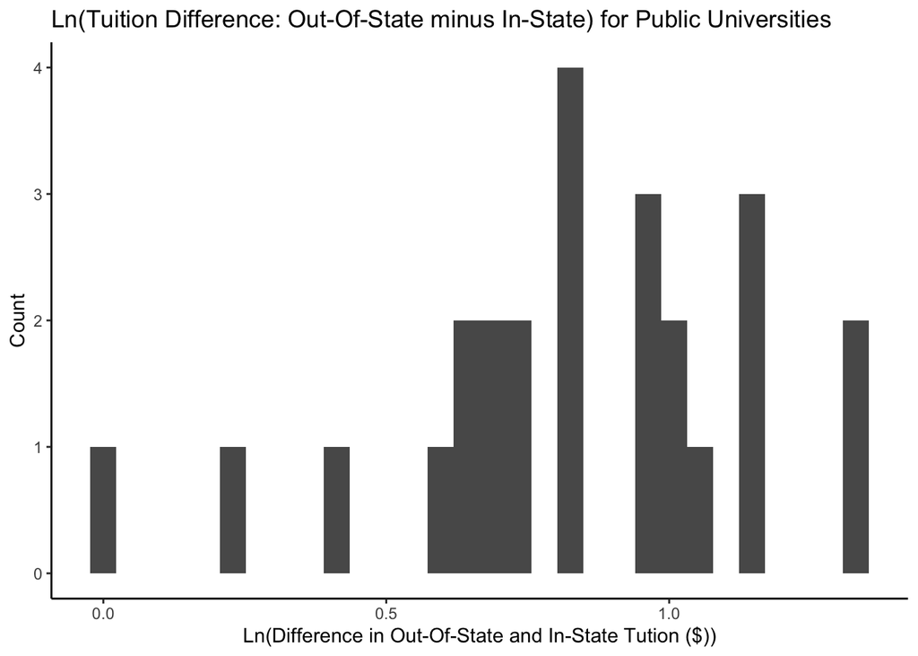

```r
#histogram of the difference in logged tuition
tuition %>%
  filter(Type == "Public") %>%
  ggplot() +
  geom_histogram(aes(x = diff_of_logs)) +
  labs(title = "Ln(Tuition Difference: Out-Of-State minus In-State) for Public Universities",
       x = "Ln(Difference in Out-Of-State and In-State Tution ($))",
       y = "Count") +
  theme_classic()
```

```r
#t-test time
#in/out of state tuition in public
tuition_public_t <- tuition_long %>%
  filter(Type == "Public") %>%
  mutate(State = as.factor(State))

t1 <- t.test(log_tuition ~ State, data = tuition_public_t, paired = TRUE)
t1
```

```
##
##  Paired t-test
##
## data:  log_tuition by State
## t = -13.058, df = 24, p-value = 2.132e-12
## alternative hypothesis: true difference in means is not equal to 0
## 95 percent confidence interval:
##  -0.9587507 -0.6970442
## sample estimates:
## mean of the differences
##              -0.8278974
```

```r
#back transform estimate and CI
exp(t1$est[1])
```

```
## mean of the differences
##               0.4369671
```

```r
exp(t1$conf.int)
```

```
## [1] 0.3833715 0.4980553
## attr(,"conf.level")
## [1] 0.95
```